# R Notebook

## And Make SOme Waffle Plots

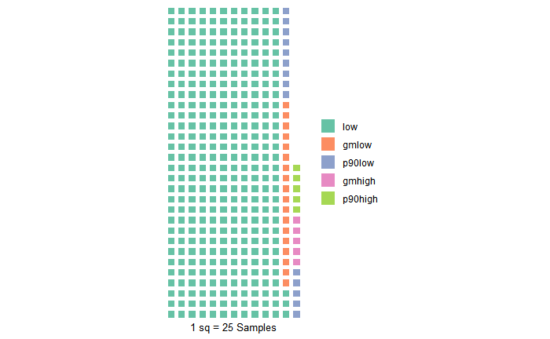

```r
wp <- waffle(tt/25, rows = 30, xlab="1 sq = 25 Samples") +
  scale_label_pictogram(labels=levels(tmp$lvls4))
wp
```

A proportional waffle plot requires using the geoms, which is slightly challenging. By setting color=fill, you can get a solid block look. Generally, you are better off with color=white, which puts whitespace between squares. You can control the width of those while lines with size=X

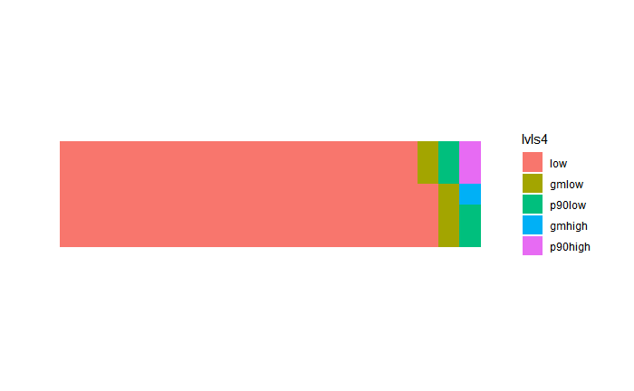

```r
wp <- ggplot(tmp, aes(fill=lvls4,values= count)) + geom_waffle(aes(color=lvls4),make_proportional = TRUE, n_rows=5)+
  scale_label_pictogram(name = '', labels=levels(tmp$lvls4)) +
  #theme_minimal() +
  theme_ipsum_rc(grid="") +
  theme_enhance_waffle()
wp
```

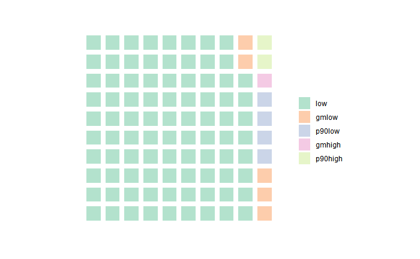

```r
wp <- ggplot(tmp, aes(fill=lvls4,values= count)) +
  geom_waffle(make_proportional = TRUE, color='white', size=3)+
  scale_fill_brewer(palette='Pastel2', name = NULL, labels = c(levels(tmp$lvls4))) +
  coord_equal() +
  #theme_minimal() +
  theme_ipsum_rc(grid="") +
  theme_enhance_waffle()
```

# Using Pictograms

## Simple Example

Making a call to waffle() works, but only if I provide a font family…

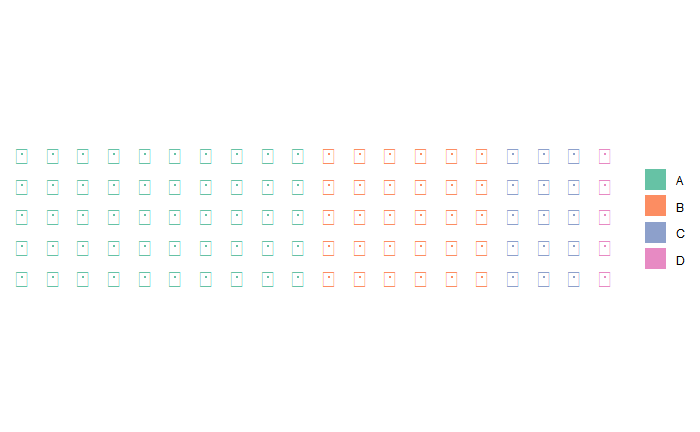

```r
waffle(c(50, 30, 15, 5), rows = 5, use_glyph = 'ambulance', glyph_size = 6)
```

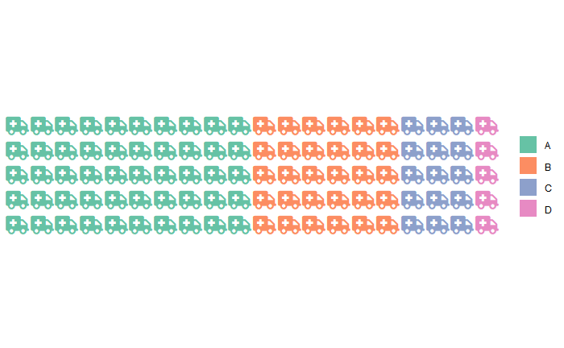

```r
waffle(c(50, 30, 15, 5), rows = 5, use_glyph = 'ambulance', glyph_font_family="Font Awesome 5 Free Solid", glyph_size = 6)
```

### Works with real data too

Here it is with our data. However, I can’t get this to work when I change the glyphs to many named glyphs shown in fa_list(). I have found no rhyme or reason for which glyphs are available.

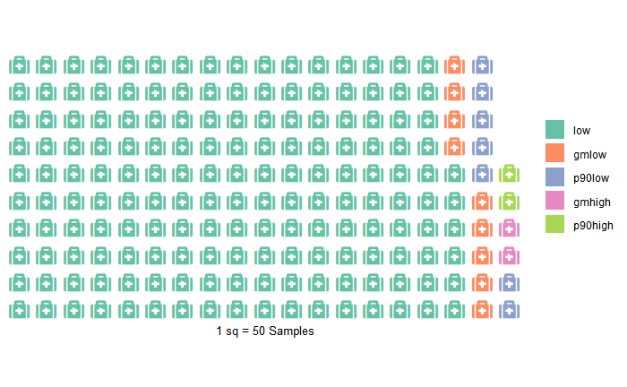

```r
wp2 <- waffle(tt/50, rows = 10, xlab="1 sq = 50 Samples",
              use_glyph = 'medkit', glyph_font_family="Font Awesome 5 Free Solid",
              glyph_size = 6)
wp2
```

# Examples using geom_pictogram

As far as I can tell, geom_opictogram provides no obvious way to specify the font family. I tried to provide a glyph_font_family=“Font Awesome 5 Free Solid”, but the parameter has no effect in ggplot, and is not recognized in geom_pictogram or scale_label_pictogram.

Note that you need to provide matching scales with identical labels to scale_color_XX() and scale_label_pictogram() if you want to see only one scale.

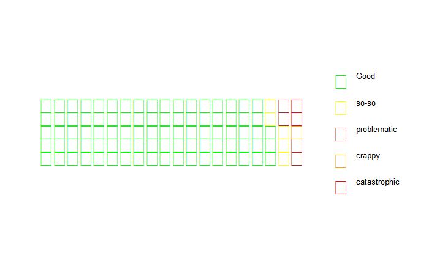

```r
wp2 <- ggplot(tmp, aes(label=lvls4, values= count) ) +    #,
              #glyph_font_family="Font Awesome 5 Free Solid") +
  geom_pictogram(n_rows=5, aes(color=lvls4),
                 make_proportional = TRUE) +  #  ,
                 #glyph_font_family="Font Awesome 5 Free Solid") +
  scale_color_manual(
    name = NULL,
    values = c("green", "yellow", "brown", "orange", "red"),
    labels = c("Good", "so-so", "problematic", "crappy", "catastrophic")) +
  scale_label_pictogram(
    name = NULL,
    values = c("apple-alt", "bread-slice", "pizza-slice", "medkit", "ambulance"),
    labels = c("Good", "so-so", "problematic", "crappy", "catastrophic")) +
  coord_equal() +
  theme_enhance_waffle() +
  theme(legend.key.height = unit(2.25, "line")) +
  theme(legend.text = element_text(size = 10, hjust = 0, vjust = 0.75))
wp2
```

And I don’t appear to be able to create a ggplot object with waffle and modify it with the geom. I tried various options here.

```r
wp2 <-waffle(tmp, glyph_font_family="Font Awesome 5 Free Solid") +
  geom_pictogram( n_rows=5,
                 make_proportional = TRUE)
wp2
```

```
Error in `[[<-.data.frame`(`*tmp*`, "values", value = numeric(0)) :
  replacement has 0 rows, data has 9450
```

The same thing happens with the demo code….

```r
data.frame(
  parts = factor(rep(month.abb[1:3], 3), levels=month.abb[1:3]),
  vals = c(10, 20, 30, 6, 14, 40, 30, 20, 10),
  col = rep(c("blue", "black", "red"), 3),
  fct = c(rep("Thing 1", 3),
          rep("Thing 2", 3),
          rep("Thing 3", 3))
) -> xdf

xdf %>%
  count(parts, wt = vals) %>%
  ggplot(aes(label = parts, values = n)) +
  geom_pictogram(n_rows = 10, aes(colour = parts),
                 flip = TRUE, make_proportional = TRUE) +
  scale_color_manual(
    name = NULL,
    values = c("#a40000", "#c68958", "#ae6056"),
    labels = c("Fruit", "Sammich", "Pizza")
  ) +
  scale_label_pictogram(
    name = NULL,
    values = c("apple-alt", "bread-slice", "pizza-slice"),
    labels = c("Fruit", "Sammich", "Pizza")
  ) +
  coord_equal() +
  theme_ipsum_rc(grid="") +
  theme_enhance_waffle() +
  theme(legend.key.height = unit(2.25, "line")) +
  theme(legend.text = element_text(size = 10, hjust = 0, vjust = 0.75))
```

[output not shown]